# Actividad 1: Preprocesamiento de los datos

Nadia Sánchez

```
## 'data.frame':    211 obs. of  11 variables:
##  $ Id      : int  2 2 3 6 8 9 11 13 14 15 ...
##  $ Estradl : chr  "94" "7.7" "20.23" "41.37" ...
##  $ Ethnic  : chr  "Caucasian" "Caucasian" "  Caucsian" "Caucasian" ...
##  $ Entage  : chr  "30" "23" "21" "33" ...
##  $ Numchild: int  0 0 0 0 0 2 9 4 0 0 ...
##  $ Agefbo  : int  0 0 0 0 0 27 99 19 0 8 ...
##  $ Anykids : int  0 0 0 0 0 1 9 1 0 0 ...
##  $ Agemenar: chr  "11,0" "15.0" "13.0" "14.0" ...
##  $ BMI     : chr  "18,9038" "20,4386" "22,2578" "20,5265" ...
##  $ WHR     : chr  "0,7" "0,7" "0,75" "0,73" ...
##  $ Area    : int  0 0 1 1 1 1 1 1 1 1 ...
```

# Carga del fichero

Al abrir el archivo con un editor de texto sencillo como el bloc de notas observamos que “;” es el símbolo separador y el punto corresponde al valor decimal. Por lo tanto, hay que leer el fichero con la función `read.csv()`.

El conjunto de datos a tratar porvienen del estudio de la relación entre la obesidad y el cáncer de mama en mujeres premenopáusicas. Los datos registrados de las mujeres en edad premenopáusica fueron: etnia, area (rural, urbana), número de hijos, edad de la mujer, edad a la que la mujer ha tenido el primer hijo, edad de la menarquia (primera menstruación), medida del estradiol (analítica hormonal), medida de la adiposidad general que corresponde al ratio peso(kg)/Altura2(m), medida de la adiposidad abdominal que corresponde al ratio cintura/cadera.

El archivo se denomina *DataEstradiol.csv*, contiene 211 registros y 11 variables. Estas variables son: Id, Estradl, Ethnic, Entage, Numchild, Agefbo, Anykids, Agemenar, BMI, WHR, Area

# Breve inspección de los datos

```r
var.factor <- c(3,7,11)
var.integer <- c(1,5)
var.numeric <- c(2,4,6,8,9,10)
var.tipo <- vector(mode="character",length=ncol(datos))
var.tipo[var.factor] <- "character"
var.tipo[var.integer] <- "integer"
var.tipo[var.numeric] <- "numeric"
```

Son variables cualitativas nominales: Ethnic, Anykids, Area

Son variables cuantitativas discretas: Id, Numchild

Son variables cuantitativas continuas: Estradl, Entage, Agefbo, Agemenar, BMI, WHR

# Formato de las variables cuantitativas

La lectura del fichero con la función `read.csv()` ha realizado la siguiente asignación a cada variable cuantitativa

```r
formato <- sapply(datos,class)

kable(data.frame(variables=names(formato[-c(3,7,11)]),clase=as.vector(formato[-c(3,7,11)])))
```

| variables | clase |
| --- | --- |
| Id | integer |
| Estradl | character |
| Entage | character |
| Numchild | integer |
| Agefbo | integer |
| Agemenar | character |
| BMI | character |
| WHR | character |

```r
var_error <- name.var[formato != var.tipo]
```

```r
var_error <- name.var[formato != var.tipo]
var_error
```

```
## [1] "Estradl"  "Entage"   "Agefbo"   "Anykids"  "Agemenar" "BMI"      "WHR"
## [8] "Area"
```

Por tanto, las variables con asignación equivocada y que es necesario corregir son: Estradl, Entage, Agefbo, Agemenar, BMI, WHR

La asignación a realizar es:

```r
tipo <- var.tipo[names(datos) %in% var_error]

kable(data.frame(variables= var_error[-c(4,8)], clase= tipo[-c(4,8)]),
      caption = "Variables cuantitativas con asignación de clase erronea")
```

Variables cuantitativas con asignación de clase erronea

| variables | clase |
| --- | --- |
| Estradl | numeric |
| Entage | numeric |
| Agefbo | numeric |
| Agemenar | numeric |
| BMI | numeric |
| WHR | numeric |

## Corregir errores de las variables cuantitativas con confusión de separador decimal

```r
#Cambiar "," por ".""

separador <- var_error[-c(3,4,8)]

for(i in 1:5){
datos[,separador[i]] <-  as.numeric( sub(",","\\.",datos[,separador[i]]) )
}

summary(datos[,separador])
```

```
##     Estradl           Entage         Agemenar          BMI
##  Min.   :  2.20   Min.   :11.00   Min.   : 9.00   Min.   :17.72
##  1st Qu.: 23.05   1st Qu.:21.00   1st Qu.:11.25   1st Qu.:21.36
##  Median : 36.80   Median :26.00   Median :12.00   Median :24.51
##  Mean   : 39.43   Mean   :25.88   Mean   :14.32   Mean   :25.78
##  3rd Qu.: 49.72   3rd Qu.:31.00   3rd Qu.:13.00   3rd Qu.:29.56
##  Max.   :332.70   Max.   :37.00   Max.   :99.00   Max.   :42.24
##       WHR
##  Min.   :0.6200
##  1st Qu.:0.7100
##  Median :0.7400
##  Mean   :0.7591
##  3rd Qu.:0.8100
##  Max.   :0.9800
```

## Convertir las variables Estradl, Entage, Agefbo, Agemenar, BMI, WHR en tipo numérico

Las variables Estradl, Entage, Agemenar, BMI, WHR fueron convertidas en tipo numérico en el paso anterior.

```r
datos[,"Agefbo"] <-  as.numeric(datos[,"Agefbo"])
```

Ahora podemos verificar que las variables Estradl, Entage, Agefbo, Agemenar, BMI, WHR son del tipo **numeric, numeric, numeric, numeric, numeric, numeric**, respectivamente.

# Valores extremos

valores extremos (outliers) en la variable Estradiol

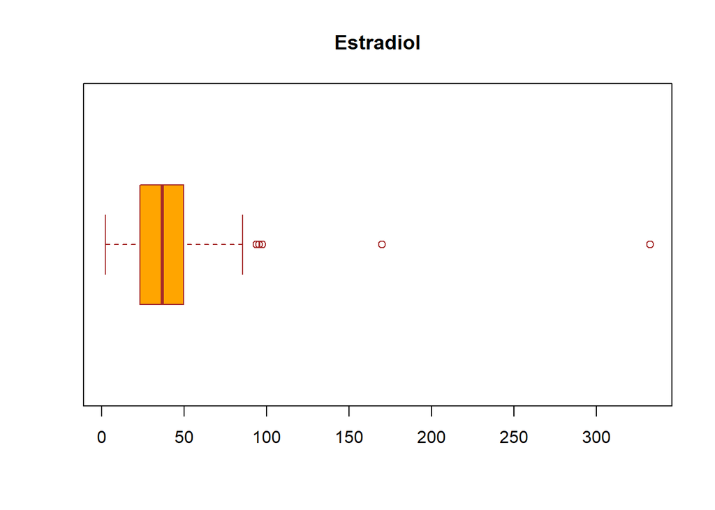

```r
boxplot(datos$Estradl, main= "Estradiol", col= "orange", border = "brown", horizontal = TRUE)
```

```r
boxplot.stats(datos$Estradl)
```

```
## $stats
## [1]  2.200 23.050 36.800 49.715 85.530
##
## $n
## [1] 211
##
## $conf
## [1] 33.8996 39.7004
##
## $out
## [1]  94.00 332.70  95.57 170.10  97.40  95.50
```

En la gráfica se observa la presencia de valores atipicos extremos.

## Eliminar valores extremos

Calculamos los valores extremos de la variable Estradiol, a partir de la normalización de dicha variable y se consideran como valores atípicos las observaciones que se encuentren a más de 3 desviaciones estándar del promedio

```r
zx<- (datos$Estradl-mean(datos$Estradl))/sd(datos$Estradl)
#indice donde se encuentran los valores extremos
which(abs(zx)>3)
```

```
## [1] 31 80
```

```r
# Valores extremos
datos$Estradl[which(zx>3)]
```

```
## [1] 332.7 170.1
```

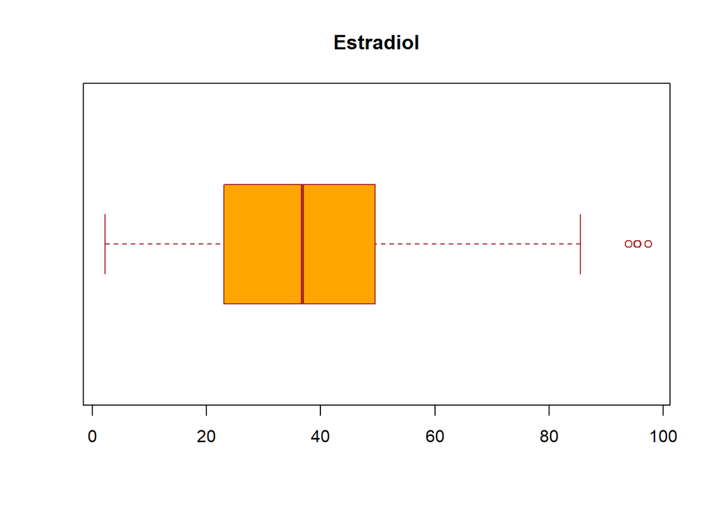

```r
#Eliminar valores
datos <- datos[-c(which(abs(zx)>3)),]
#Diagrama de caja con valores finales
boxplot(datos$Estradl, main= "Estradiol", col= "orange", border = "brown", horizontal = TRUE)
```

# Valores del resto de variables cuantitativas

## Presentar un boxplot para cada variable cuantitativa

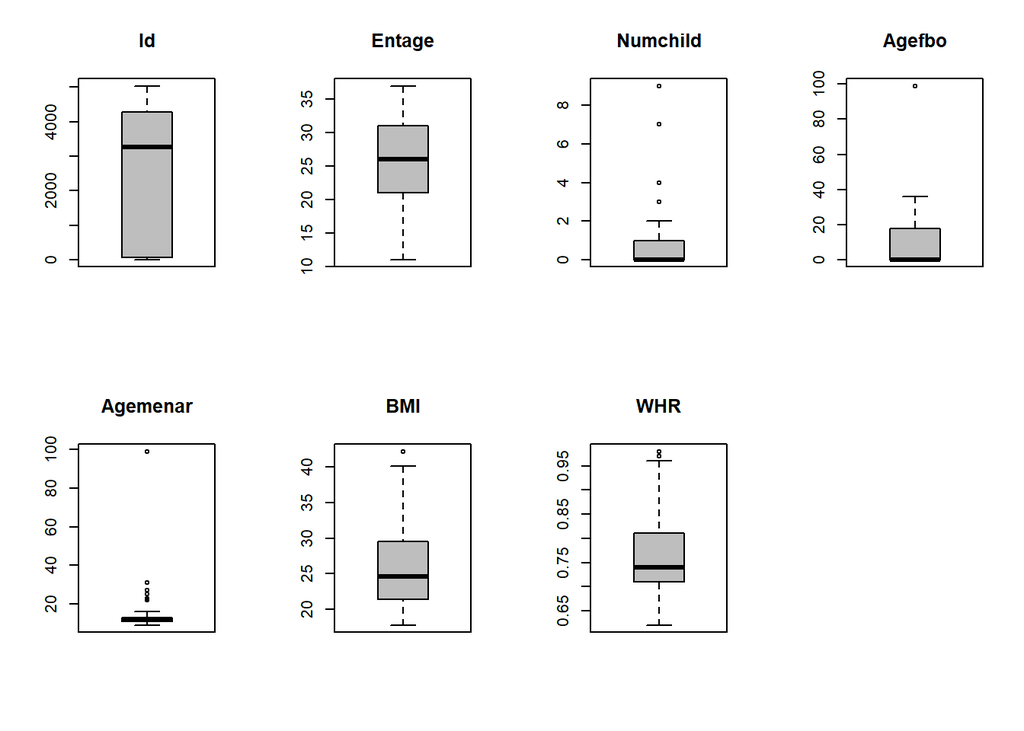

```r
resto <- sapply(datos,class)
resto <- which(resto=="numeric" | resto=="integer")
v.cuant <- resto[-c(2,6,10)]

#
par(mfrow=c(2,4))
for (i in 1:7){
  boxplot(datos[,v.cuant[i]], main=names(datos)[v.cuant[i]],col="gray")
}
```

```r
# Outlier values
vars.cuantitativas <- v.cuant
for(i in 1:length(vars.cuantitativas) ) {

  kk <- boxplot.stats(datos[,vars.cuantitativas[i]])$out
  cat(names(datos)[vars.cuantitativas[i]],":", toString(kk), "\n" )

}
```

```
## Id :
## Entage :
## Numchild : 9, 4, 9, 4, 7, 3, 9, 3, 3, 4, 3, 3, 3, 9, 3, 9, 3, 4
## Agefbo : 99, 99, 99, 99, 99, 99
## Agemenar : 31, 22, 99, 25, 99, 99, 23, 27, 99
## BMI : 42.2424
## WHR : 0.97, 0.98
```

Las variables con valores extremos son: Numchild, Agefbo, Agemenar, BMI, WHR.

En el caso de las variables: **Numchild**, **Agefbo**, **Agemenarde** al tener un valores “99”,“9”son considerados como un valor centinela, por esta razón sustituimos estos valores por NA. En estos casos los valores centinelas que son detectados como valor atípico corresponden a valores perdidos (missing). El resto de variables presentan valores atípicos que no se pueden considerar erróneos.

```r
val.centinela <- 99
# Sustituir el valor centinela por NA
datos$Agefbo[datos$Agefbo== val.centinela]<- NA
 # verificar resultado
 summary(datos$Agefbo)
```

```
##    Min. 1st Qu.  Median    Mean 3rd Qu.    Max.    NA's
##   0.000   0.000   0.000   6.532  17.000  36.000       6
```

```r
 #Agemenar
 # Sustituir el valor centinela por NA
datos$Agemenar[datos$Agemenar== val.centinela]<- NA
 # verificar resultado
 summary(datos$Agemenar)
```

```
##    Min. 1st Qu.  Median    Mean 3rd Qu.    Max.    NA's
##    9.00   11.00   12.00   12.68   13.00   31.00       4
```

```r
 #Numchild
 # Sustituir el valor centinela por NA
datos$Numchild[datos$Numchild== 9]<- NA
 # verificar resultado
 summary(datos$Agemenar)
```

```
##    Min. 1st Qu.  Median    Mean 3rd Qu.    Max.    NA's
##    9.00   11.00   12.00   12.68   13.00   31.00       4
```

# Inconsistensias

## Variables Numchild y Anykids.

La inconsistencia se produce cuando Anykids es igual a 0 y Numchild es mayor a 0, ó si Numchild es mayor 0 y Anykids mayor a 1.El criterio de corrección es asignar el valor de 1 a Anykids.

### Caso 1 Anykids = 0 y Numchild > 0

```r
# find wrong values
kk <- which(datos$Anykids == 0 & datos$Numchild > 0)
```

Han aparecido 0 individuos con esta inconsistencia.

```r
# find wrong values
kk <- which(datos$Anykids > 1 & datos$Numchild > 0)
```

Han aparecido 3 individuos con esta inconsistencia.

```r
kable(t(datos[kk,c(5,7)]))
```

|  | 47 | 71 | 178 |
| --- | --- | --- | --- |
| Numchild | 2 | 4 | 3 |
| Anykids | 2 | 4 | 3 |

El siguiente paso es corregirlo:

El valor a ajustar es el de Anykids, ya que tiene valores mayores a 1, estos valores los pasan a ser igual a 1 que significa que tiene hijos, ya que el número de hijos es mayor a 0.

```r
datos[kk,7]<- 1
```

## Variables Entage y Agemenarq.

La inconsistencias entre Entage y Agemenar se produce si Agemenarq es superior a EntAge, probablemente se debe a un error al introducir los datos y por tanto, hay que intercambiar los valores

```r
# find wrong values
kk <- which(datos$Entage < datos$Agemenar  )
```

Han aparecido 5 individuos con esta inconsistencia.

Y los valores inconsistentes son:

```r
kable(t(datos[kk,c(4,8)]))
```

|  | 53 | 55 | 126 | 152 | 157 |
| --- | --- | --- | --- | --- | --- |
| Entage | 16 | 12 | 11 | 13 | 13 |
| Agemenar | 31 | 22 | 25 | 23 | 27 |

El siguiente paso es corregirlo:

```r
swap(datos[kk,4],datos[kk,8])
```

Y para comprobar la correción volvemos hacer la comprobación:

```r
kable(t(datos[kk,c(4,8)]))
```

|  | 53 | 55 | 126 | 152 | 157 |
| --- | --- | --- | --- | --- | --- |
| Entage | 31 | 22 | 25 | 23 | 27 |
| Agemenar | 16 | 12 | 11 | 13 | 13 |

## Variables Agefbo, Agemenarq y Numchild.

Agefbo debe ser superior a Agemenar si la mujer ha tenido algún hijo. Toma el valor 0 en caso contrario.

### Caso:1 Agefbo > Agemenar

```r
# find wrong values
kk <- which(datos$Agefbo > datos$Agemenar & datos$Numchild == 0 )
```

Han aparecido 2 individuos con esta inconsistencia. Los registros son: 61, 67

Y los valores inconsistentes son:

```r
kable(t(datos[kk,c(5,6,8)]))
```

|  | 62 | 68 |
| --- | --- | --- |
| Numchild | 0 | 0 |
| Agefbo | 36 | 34 |
| Agemenar | 11 | 11 |

El siguiente paso es corregirlo:

```r
datos[kk,6] <- 0
```

### Caso:2 Agefbo < Agemenar

```r
# find wrong values
kk <- which(datos$Agefbo < datos$Agemenar & datos$Numchild == 0 & datos$Agefbo > 0)
```

Han aparecido 4 individuos con esta inconsistencia. Los registros son: 10, 44, 47, 133

Y los valores inconsistentes son:

```r
kable(t(datos[kk,c(5,6,8)]))
```

|  | 10 | 45 | 48 | 135 |
| --- | --- | --- | --- | --- |
| Numchild | 0 | 0 | 0 | 0 |
| Agefbo | 8 | 6 | 7 | 4 |
| Agemenar | 13 | 12 | 14 | 12 |

El siguiente paso es corregirlo:

```r
datos[kk,6] <- 0
```

# Formato de las variables cualitativas

Estandarizar/normalizar las variables cualitativas, según los criterios establecidos.

## Variable Ethnic

Se estandarizan en “African American” y “Caucasian”.

El primer paso es mostrar la tabla con los valores de las diferentes etnias registradas y sus frecuencias. De esta manera se pueden observar si existe algunos problemas.

```r
table(datos$Ethnic)
```

```
##
##    African American                  Caucsian                  Af Am
##                     11                     11                     17
##       African american       African American              Caucacian
##                     22                    101                      3
##              Caucasian               Caucsian
##                     42                      2
```

1. Quitar espacios antes y después de cada valor observado. El resultado es:

```r
kk <- trimws( datos$Ethnic )
table(kk )
```

```
## kk
##            Af Am African american African American        Caucacian
##               17               22              112                3
##        Caucasian         Caucsian
##               42               13
```

2. Pasar a formato título los valores observados. El resultado es:

```r
kk <- str_to_title(kk)
table(kk)
```

```
## kk
##            Af Am African American        Caucacian        Caucasian
##               17              134                3               42
##         Caucsian
##               13
```

3.Cambiamos

```r
kk <- sub("Af Am","African American",kk)
kk <- sub("Caucacian","Caucasian",kk)
kk <- sub("Caucsian","Caucasian",kk)
# Update
datos$Ethnic <-as.factor(kk)
```

Para comprobar los cambios se presenta la tabla de frecuencias.

```r
table(datos$Ethnic)
```

```
##
## African American        Caucasian
##              151               58
```

## Variable Anykids

Se estandarizan en “Yes” (valor 1 en el archivo), y “No” (valor 0).

```r
table(datos$Anykids)
```

```
##
##   0   1   9
## 146  58   5
```

En este caso sólo es necesario utilizar la función `factor()` con la codificación adecuada de acuerdo al criterio: 1 igual a Yes, 0 igual a No

```r
datos[,var_error[4]] <- factor(datos[,var_error[4]], levels= c(0,1), labels= c("No","Yes"))

table(datos[,var_error[4]])
```

```
##
##  No Yes
## 146  58
```

```r
table(datos$Area)
```

```
##
##   0   1
##  66 143
```

En este caso sólo es necesario utilizar la función `factor()` con la codificación adecuada de acuerdo al criterio: 1 igual a Rural, 0 igual a Urban

```r
datos[,var_error[8]] <- factor(datos[,var_error[8]], levels= c(0,1), labels= c("Urban","Rural"))

table(datos[,var_error[8]])
```

```
##
## Urban Rural
##    66   143
```

Ahora podemos verificar que la variable Area es del tipo **factor**.

# Imputación

Las variables que tienen valores perdidos son:

**Numchild, Agefbo, Anykids, Agemenar**

```r
v.missing <- which(colSums(is.na(datos)) >0 )
v.missing
```

```
## Numchild   Agefbo  Anykids Agemenar
##        5        6        7        8
```

## Imputar los valores a partir de los k-vecinos más cercanos usando la distancia de Gower con la información de las variables cuantitativas y los datos de la misma etnia.

Para imputar los valores perdidos dividimos el dataset por Ethnic (African American, Caucasian), para realizar la imputación de Agemenar.

### Caso African American Agemenar

```r
#Filtrado por etnia
df<- filter(datos, datos$Ethnic == "African American")
df3<-df
df2<- filter(datos, datos$Ethnic == "Caucasian")

#Agemenar
output<- kNN( df3[ -c(7,11)], variable="Agemenar", k=3 )
df<-subset(output, select = 1:9)
df3$Agemenar<-as.numeric(df$Agemenar)
```

### Caso Numchild Agefbo Anykids

En este caso utilizamos el conjunto de datos completo con los valores imputados de Agemenar

```r
#Agrupamos el dataset
datos2 <-rbind(df3, df2)

df<- datos2

#Agefbo
output<- kNN( datos2[ -c(7,11)], variable="Agefbo", k=3 )
df<-subset(output, select = 1:9)
datos2$Agefbo<-as.numeric(df$Agefbo)

#Numchild
output<- kNN( datos2[ -c(7,11)], variable="Numchild", k=3 )
df<-subset(output, select = 1:9)
datos2$Numchild<-as.numeric(df$Numchild)

#Anykids
output<- kNN( datos2[ -c(11)], variable="Anykids", k=3 )
df<-subset(output, select = 1:9)
datos2$Anykids<-as.factor(df$Anykids)

colSums(is.na(datos2))
```

```
##       Id  Estradl   Ethnic   Entage Numchild   Agefbo  Anykids Agemenar
##        0        0        0        0        0        0        0        0
##      BMI      WHR     Area
##        0        0        0
```

Como podemos observar no existen valores perdidos.

# Tabla resumen de las variables cualitativas

Se presenta un resumen descriptivo de los valores de las variables cualitativas.

```r
options(knitr.kable.NA = '')

kable(summary(datos2)[,var.factor],
      digits=2, align='l', caption="Estadística descriptiva de variables cualitativas")
```

Estadística descriptiva de variables cualitativas

|  | Ethnic | Anykids | Area |
| --- | --- | --- | --- |
|  | African American:151 | No :147 | Urban: 66 |
|  | Caucasian : 58 | Yes: 62 | Rural:143 |

# Tabla resumen de las variables cuantitativas

Se presenta una tabla de la tendencia central y dispersión de las variables cuantitativas. Usando medidas robustas y no robustas.

```r
mean.n <- as.vector(sapply( datos2[,vars.cuantitativas ],mean,na.rm=TRUE ) )
std.n <- as.vector(sapply(datos2[,vars.cuantitativas ],sd, na.rm=TRUE))
median.n <- as.vector(sapply(datos2[,vars.cuantitativas],median, na.rm=TRUE))
mean.trim.0.05 <- as.vector(sapply(datos2[,vars.cuantitativas],mean, na.rm=TRUE, trim=0.05))
mean.winsor.0.05 <- as.vector(sapply(datos2[,vars.cuantitativas],winsor.mean, na.rm=TRUE,trim=0.05))
IQR.n <- as.vector(sapply(datos2[,vars.cuantitativas],IQR, na.rm=TRUE))
mad.n <- as.vector(sapply(datos2[,vars.cuantitativas],mad, na.rm=TRUE))


kable(data.frame(variables= names(datos2)[vars.cuantitativas],
                 Media = mean.n,
                 Mediana = median.n,
                 Media.recort.0.05= mean.trim.0.05,
                 Media.winsor.0.05= mean.winsor.0.05
                 ),
      digits=2, caption="Estimaciones de Tendencia Central")
```

Estimaciones de Tendencia Central

| variables | Media | Mediana | Media.recort.0.05 | Media.winsor.0.05 |
| --- | --- | --- | --- | --- |
| Id | 2487.15 | 3270.00 | 2483.68 | 2487.16 |
| Entage | 26.13 | 26.00 | 26.07 | 26.11 |
| Numchild | 0.55 | 0.00 | 0.40 | 0.51 |
| Agefbo | 6.35 | 0.00 | 5.47 | 6.20 |
| Agemenar | 12.37 | 12.00 | 12.34 | 12.35 |
| BMI | 25.83 | 24.55 | 25.57 | 25.76 |
| WHR | 0.76 | 0.74 | 0.76 | 0.76 |

```r
kable(data.frame(variables= names(datos2)[vars.cuantitativas],
                 Desv.Standard = std.n,
                 IQR = IQR.n,
                 MAD = mad.n
                 ),
      digits=2, caption="Estimaciones de Dispersión")
```

Estimaciones de Dispersión

| variables | Desv.Standard | IQR | MAD |
| --- | --- | --- | --- |
| Id | 2046.06 | 4208.00 | 2590.10 |
| Entage | 5.41 | 10.00 | 7.41 |
| Numchild | 1.06 | 1.00 | 0.00 |
| Agefbo | 10.11 | 17.00 | 0.00 |
| Agemenar | 1.38 | 2.00 | 1.48 |
| BMI | 5.41 | 8.14 | 5.35 |
| WHR | 0.07 | 0.10 | 0.06 |

Las variables **Numchild** y **Agefbo** son las que tienen valores más diferentes, las medidas robustas discrepan bastante de las ordinarias debido a que los datos contienen un gran número de ceros.

# Grabar a un archivo

Grabar los datos preprocesados a un fichero final denominado: “ESTRADL_clean.csv”

```r
df.newfile <- "ESTRADL_clean.csv"
write.csv(datos2, file=df.newfile, row.names = FALSE)
```

# Referencias

[1] D. Jankovich, «dinajankovich, My journey to Data Science,» [En línea]. Available: https://dinajankovich.com/2018/04/28/k-means-clustering-of-wine-data/. [Último acceso: 22 Octubre 2019].

[2] Ihaka R. & Gentleman R. 1996. R: a language for data analysis and graphics. Journal of Computational and Graphical Statistics 5: 299–314.